# Word Prediction Project - Milestone Report

Justin Z

June 30, 2019

## Overview

This is the first milestone report for my word prediction project which is for the capstone project of the Data Science Specialization from Johns Hopkins University on Coursera. The ultimate goal of the project is to create an application that uses a model to predict which word comes next based on a sequence of input words. The instructions for this milestone report say to create an HTML report which summarizes the text files that will eventually form the basis of the predictive model. The report should include figures that show interesting features identified during exploratory data analysis.

The data for this project were downloaded through the course website and pre-processed in RStudio. The data were then explored for interesting features that will guide the remaining portions of the project. The `quanteda` and `tidyverse` packages were used for much of the data processing. Additional information such as the full instructions, a link to the raw data, the initial script, and the R Markdown file that produced this report can be found in the [GitHub repo](https://github.com/jtzingsheim1/text-prediction-model-and-app) for this project.

## Introduction

A core part of the broader project is to create a predictive text model, and an effective model should have a large and diverse sample dataset to train on. The course provides a large dataset which was obtained with a web crawler, and the sources include: blogs, news articles, and Twitter. Data were collected in four languages, but this project will only focus on English data. The table below summarizes the three files that were provided in the English language.

| File Name | File Size [Mb] | Number of Lines | Number of Words |
| --- | --- | --- | --- |
| en_US.blogs.txt | 200.4 | 899288 | 37740674 |
| en_US.news.txt | 196.3 | 77259 | 2623621 |
| en_US.twitter.txt | 159.4 | 2360148 | 29768062 |

The table shows that the combined file size is over 500 Mb, so care must be taken since this data could strain the memory and processing resources of a computer. The word count listed in the table is after some light pre-processing which removed some elements like numbers, urls, and twitter handles. Elements like these can be removed since the predictive model will not attempt to predict these types of features.

The [quanteda tutorial site](https://tutorials.quanteda.io/) has a great image (shown below) which shows how a typical natural language processing workflow might progress when using the `quanteda` package.

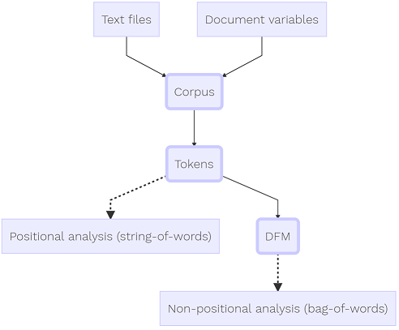

This project has so far used a similar workflow - texts were each loaded in line by line and then processed into corpus objects. These were then tokenized, where each line was split into individual words. During tokenization some elements were removed as described above. The token objects were then combined into a single object representing all of the texts, and this combined token object was the foundation of the rest of the exploration process. This report starts with non-positional analysis and then moves on to positional analysis.

## Non-Positional Analysis (Unigrams)

The combined token object was then organized into a document-feature matrix, and in this form some interesting insights can be extracted from the data. For example, one can see that the texts contained 0.6 million unique words with 70.1 million total occurances of words (the word count). If the list of unique words is sorted by decreasing frequency, one can see how the frequencies and cumulative occurance fraction change along the word index as shown in the plots below.

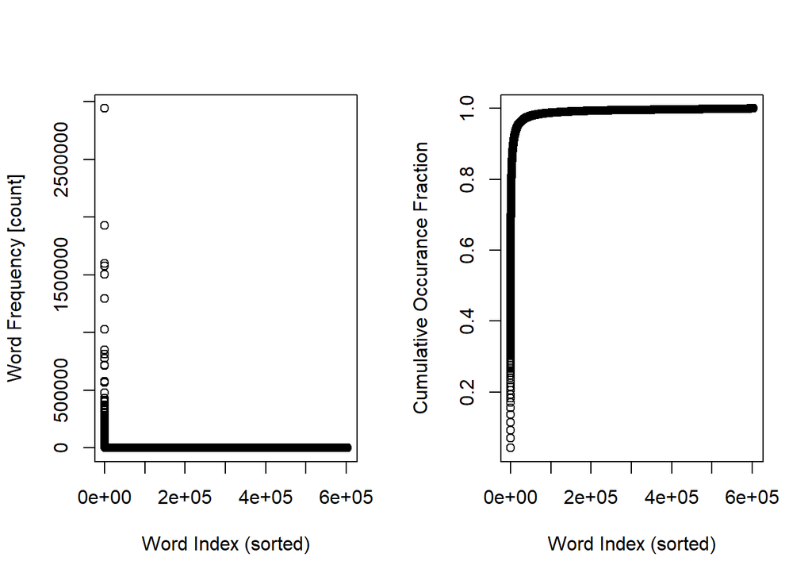

| Coverage Fraction | Words Needed |
| --- | --- |
| 0.1 | 3 |
| 0.2 | 9 |
| 0.5 | 125 |
| 0.9 | 6875 |

The plot above on the left shows that a very small number of words occur very frequently, and then there is a long tail of words that occur rarely. This sharp inverse relationship is [common in NLP](https://en.wikipedia.org/wiki/Zipf%27s_law). Similarily the plot on the right shows how the total fraction of occurances quickly spikes and then slowly increases as more words are included. The table above summarizes this plot by showing how many words are needed to cover certain fractions of occurances. It is worth taking a closer look at these most common words in the table below.

| n-gram | Frequency | Rank | Document Frequency |
| --- | --- | --- | --- |
| the | 2942610 | 1 | 1337700 |
| to | 1926898 | 2 | 1145143 |
| and | 1600371 | 3 | 905880 |
| a | 1577898 | 4 | 978654 |
| i | 1503845 | 5 | 877281 |
| of | 1295395 | 6 | 767017 |
| in | 1029596 | 7 | 716756 |
| you | 850321 | 8 | 615522 |
| is | 812364 | 9 | 603883 |
| for | 775647 | 10 | 622886 |

The word list above is not surprising, and it is a good sign that the source text is representative of typical English and that the processing method functioned well. While this section only considered individual words and their frequencies, the next section on positional analysis will consider how words appear together.

## Positional Analysis (Bigrams and Trigrams)

In order to perform positional analysis the tokens object was processed into sequences of two words - also known as bigrams. There are many more permutations of pairs of words than there are permutations of single words. In this case there are 10.5 million bigrams. With a long tail of low frequency features, the bigrams are more skewed than the unigrams. Bigrams will form an important part of the predictive model since they provide insight on how words appear together in pairs. The table below shows the five most common bigrams in this dataset.

| n-gram | Frequency | Rank | Document Frequency |
| --- | --- | --- | --- |
| of_the | 258264 | 1 | 206699 |
| in_the | 246163 | 2 | 212183 |
| for_the | 137343 | 3 | 130297 |
| to_the | 135842 | 4 | 123301 |
| on_the | 129331 | 5 | 118722 |

As with the unigrams, these bigrams are expected. Lastly, the tokens object was processed into sequences of three words - also known as trigrams. With 32.1 million trigrams it is clear there are even more permutations than there were of bigrams, and the tail of low frequency combinations is even longer. Trigrams will also contribute to the model by showing how sequences of three words are likely to appear, and the table below shows the five most common sequences.

| n-gram | Frequency | Rank | Document Frequency |
| --- | --- | --- | --- |
| thanks_for_the | 23802 | 1 | 23772 |
| one_of_the | 21050 | 2 | 20421 |
| a_lot_of | 19328 | 3 | 18395 |
| to_be_a | 13191 | 4 | 12913 |
| i_want_to | 13176 | 5 | 12461 |

## Plans for Algorithm and Application

Considering the size of the corpus it will be critical to efficiently store and process the data. However, as large as the data set is, it still does not contain all possible words let alone all possible combinations of words. Clearly the prediction model must have a way to assign a non-zero probability to words and sequences that were not found in the corpus. I believe a similar concept can be applied to the long tails of low frequency n-grams that are found in the corpus. It may be possible to assign these tails non-zero probabilities without directly accounting for them in the model.

Additional cleaning is still needed on the data, but after that I plan to use machine learning to train the model on a training set and evaluate it on a validation set. I aim to find an effective sampling method that will allow the model to train and predict on a smaller dataset. If the model can be built to produce a vector of recommended words which are sorted by the model’s estimate of their likelihood, then the model could be evaluated both by how often it predicts the correct word, and by how close the correct word is to being the top prediction.

Once the model is built, a `Shiny` application will be created to predict text using the model. For now I plan to have a simple text box input and an action button which the user can click to view the predictions for the next word. This is less natural than an application that is continuously predicting text as the user types, but it will reduce the amount of computation required since the model will only make a prediction when it is instructed to do so by the action button.